# Kinnex Single Cell Vignette

Installing basic dependencies:

```r
install_if_missing <- function(packages) {
    if (length(setdiff(packages, rownames(installed.packages()))) > 0) {
        install.packages(setdiff(packages, rownames(installed.packages())))
    }
}
```

```r
install_if_missing(c('tidyverse','stringr','dplyr', 'edgeR', 'ggrepel','DESeq2','Seurat','clustermole'))
```

```r
library(tidyverse)
library(DESeq2)
library(dplyr)
```

Analysing sparse matrices created above

```r
knitr::opts_chunk$set(echo = TRUE)
    library(tidyverse)
    library(Seurat)
```

PW dir= ‘/Users/akhorgad/Desktop/MDL/RTD/scIsoquantMatrixBuilder_Results’

Input counts matrix created above from step1:

```r
data_dir = "/Users/akhorgad/Desktop/MDL/RTD/kinnex_sc/scIsoquantMatrixBuilder_Results/PBMC_BioIVT_10x3p_500cells.genes-sc_matrix_from_isoquant/"

output_prefix = "scKinnex.genes"
```

Reading data in using Read10x() :

```r
data = Read10X(data.dir=data_dir,
           gene.column = 1,
           cell.column = 2,
           unique.features = TRUE,
           strip.suffix = FALSE)
```

UMI counts per cell:

```r
umi_counts_per_cell = colSums(data)
```

sorting:

```r
umi_counts_per_cell = sort(umi_counts_per_cell, decreasing = T)
```

plotting :

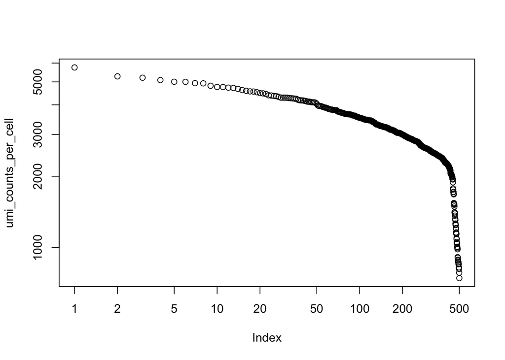

```r
plot(umi_counts_per_cell, log='xy')
```

```r
ggsave(filename='umi_counts_per_cell.png',path='/Users/akhorgad/Desktop/MDL/RTD/kinnex_sc/scIsoquantMatrixBuilder_Results', plot = last_plot())
```

Creating seurat object from counts matrix:

```r
seurat_obj <- CreateSeuratObject(counts = data, project = "scKinnex", min.cells = 3, min.features = 200)
```

```
## Warning: Feature names cannot have underscores ('_'), replacing with dashes
## ('-')
```

```r
seurat_obj
```

```
## An object of class Seurat
## 11390 features across 500 samples within 1 assay
## Active assay: RNA (11390 features, 0 variable features)
##  1 layer present: counts
```

Terminal Out: Warning: Feature names cannot have underscores (’_‘), replacing with dashes (’-’)An object of class Seurat 11390 features across 500 samples within 1 assay Active assay: RNA (11390 features, 0 variable features) 1 layer present: counts

```r
# before filtering
seurat_obj@meta.data %>% summarize(median(nCount_RNA), median(nFeature_RNA))
```

```
##   median(nCount_RNA) median(nFeature_RNA)
## 1            2794.17                  799
```

Terminal Out:

median(nCount_RNA) median(nFeature_RNA)  
2794.17 799

PercentageFeatureSet - Calculate the percentage of all counts that belong to a given set of features

```r
seurat_obj[["percent.mt"]] <- PercentageFeatureSet(seurat_obj, pattern = "^MT-")
```

exploring seurat object:

```r
seurat_obj
```

```
## An object of class Seurat
## 11390 features across 500 samples within 1 assay
## Active assay: RNA (11390 features, 0 variable features)
##  1 layer present: counts
```

```r
seurat_obj@meta.data %>% head()
```

```
##                  orig.ident nCount_RNA nFeature_RNA percent.mt
## AAAGGCCGACGGCTGT   scKinnex    2542.28          652  13.334487
## AAAGGGCACTCCAAAC   scKinnex    2829.27          822  11.769820
## AAAGGTTGAAGTTACC   scKinnex     900.31          377  22.603326
## AAAGGTTGATGGCCTG   scKinnex    3405.87         1017   9.865321
## AAAGTCGCTCCATGGC   scKinnex    2256.34          642  17.373268
## AACAGATGACGTTGGC   scKinnex    3644.29          871   4.994114
```

UMI counts per cell:

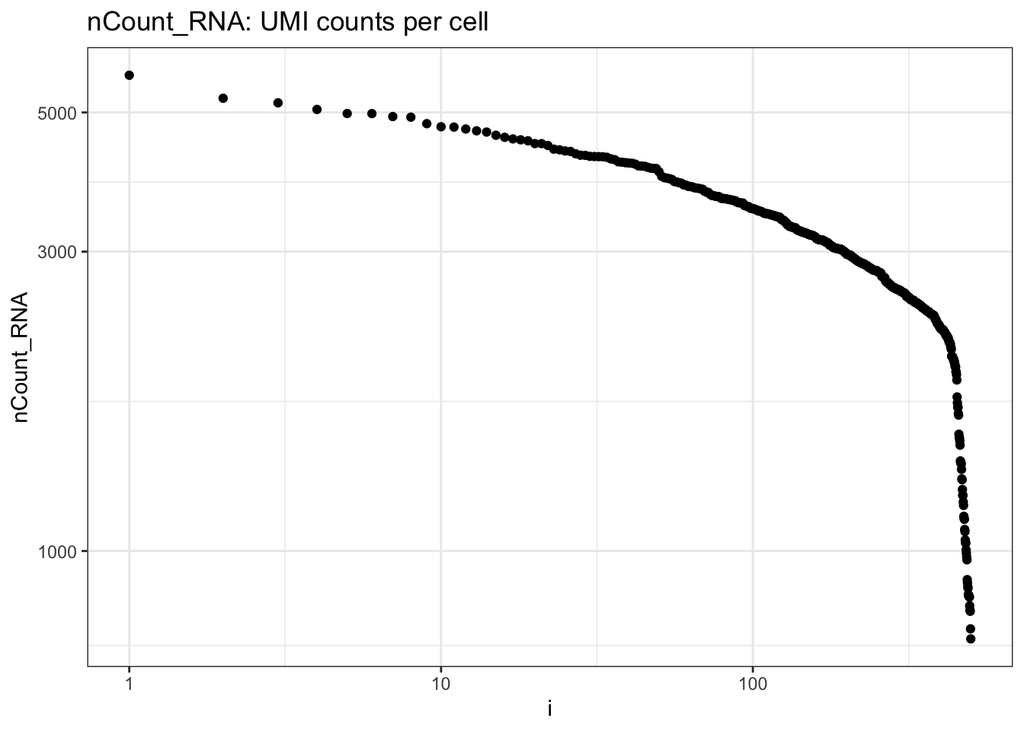

```r
seurat_obj@meta.data %>% dplyr::select(nCount_RNA) %>% arrange(desc(nCount_RNA)) %>% mutate(i=row_number()) %>%
  ggplot(aes(x=i, y=nCount_RNA)) + geom_point() + theme_bw() +
  scale_y_continuous(trans='log10') +
  scale_x_continuous(trans='log10') +

  ggtitle("nCount_RNA: UMI counts per cell")
```

```r
ggsave(filename='nCount_RNA-umi_counts_per_cell.png',path='/Users/akhorgad/Desktop/MDL/RTD/kinnex_sc/scIsoquantMatrixBuilder_Results', plot = last_plot())
```

Feature counts per cell:

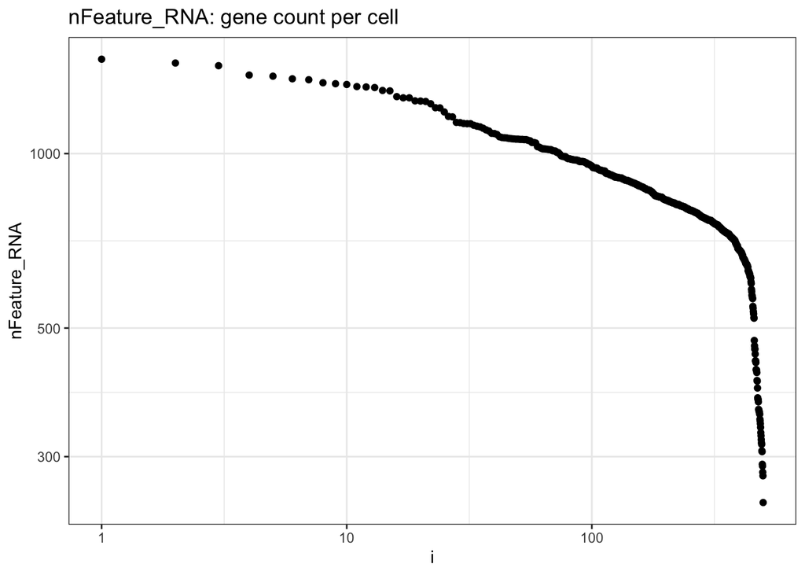

```r
seurat_obj@meta.data %>% dplyr::select(nFeature_RNA) %>% arrange(desc(nFeature_RNA)) %>% mutate(i=row_number()) %>%
  ggplot(aes(x=i, y=nFeature_RNA)) + geom_point() + theme_bw() +
  scale_y_continuous(trans='log10') +
  scale_x_continuous(trans='log10') +
  ggtitle("nFeature_RNA: gene count per cell")
```

```r
#ggsave(filename='nFeature_RNA-gene_count_per_cell.png',path='/Users/akhorgad/Desktop/MDL/RTD/kinnex_sc/scIsoquantMatrixBuilder_Results', plot = last_plot())
```

# Visualize QC metrics as a violin plot

VlnPlot: Draws a violin plot of single cell data (gene expression, metrics, PC scores, etc.)

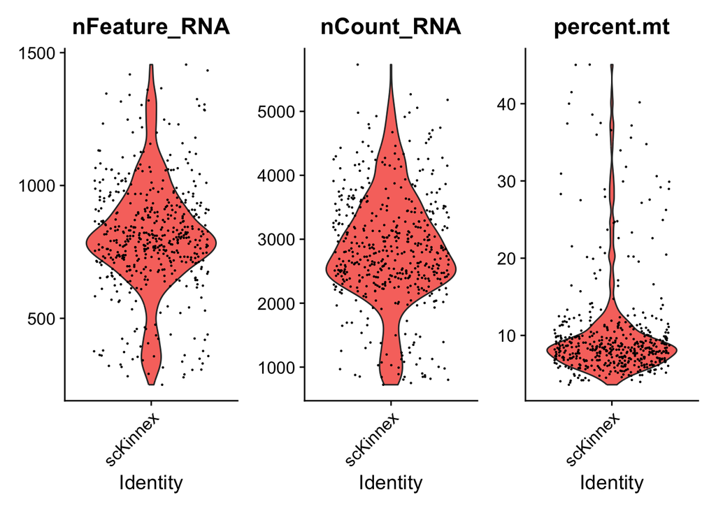

```r
VlnPlot(seurat_obj, features = c("nFeature_RNA", "nCount_RNA", "percent.mt"), ncol = 3)
```

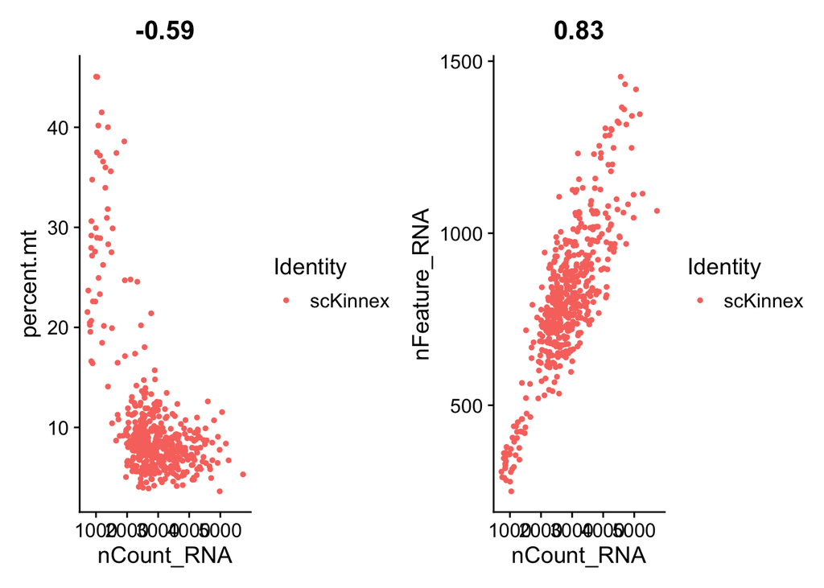

```r
ggsave(filename='VlnPlot.png',path='/Users/akhorgad/Desktop/MDL/RTD/kinnex_sc/scIsoquantMatrixBuilder_Results', plot = last_plot())
plot1 <- FeatureScatter(seurat_obj, feature1 = "nCount_RNA", feature2 = "percent.mt")
plot2 <- FeatureScatter(seurat_obj, feature1 = "nCount_RNA", feature2 = "nFeature_RNA")
plot1 + plot2
```

```r
ggsave(filename='FeatureScatter.png',path='/Users/akhorgad/Desktop/MDL/RTD/kinnex_sc/scIsoquantMatrixBuilder_Results', plot = last_plot())
```

Saving object.RDS

```r
# save before filtering

#saveRDS(seurat_obj, file = paste0(data_dir, output_prefix, "-seurat_obj-preCellFiltering.rds"))
```

filtering cells on percent Mitochondria

```r
#### filtering cells on
length(seurat_obj$percent.mt < 15)
```

```
## [1] 500
```

```r
seurat_obj <- subset(seurat_obj,
                     percent.mt < 15)

seurat_obj
```

```
## An object of class Seurat
## 11390 features across 447 samples within 1 assay
## Active assay: RNA (11390 features, 0 variable features)
##  1 layer present: counts
```

An object of class Seurat 11390 features across 447 samples within 1 assay Active assay: RNA (11390 features, 0 variable features) 1 layer present: counts

Summarize:

```r
seurat_obj@meta.data %>% summarize(median(nCount_RNA), median(nFeature_RNA))
```

```
##   median(nCount_RNA) median(nFeature_RNA)
## 1            2870.08                  817
```

Temrinal Output: median(nCount_RNA) median(nFeature_RNA) 2870.08 817

NormalizeData : Normalize the count data present in a given assay. Normalization methods = “LogNormalize”: Feature counts for each cell are divided by the total counts for that cell and multiplied by the scale.factor. This is then natural-log transformed using log1p

```r
seurat_obj <- NormalizeData(seurat_obj, normalization.method = "LogNormalize", scale.factor = 10000, verbose = TRUE)
```

```
## Normalizing layer: counts
```

FindVariableFeatures: Identifies features that are outliers on a ‘mean variability plot’. selection.method = “vst”: First, fits a line to the relationship of log(variance) and log(mean) using local polynomial regression (loess). Then standardizes the feature values using the observed mean and expected variance (given by the fitted line). Feature variance is then calculated on the standardized values after clipping to a maximum (see clip.max parameter).

```r
seurat_obj <- FindVariableFeatures(seurat_obj, selection.method = "vst", nfeatures = 2000)
```

```
## Finding variable features for layer counts
```

```r
# Identify the 10 most highly variable genes
top10 <- head(VariableFeatures(seurat_obj), 10)

# plot variable features with and without labels
plot1 <- VariableFeaturePlot(seurat_obj)
plot2 <- LabelPoints(plot = plot1, points = top10, repel = TRUE)
```

```
## When using repel, set xnudge and ynudge to 0 for optimal results
```

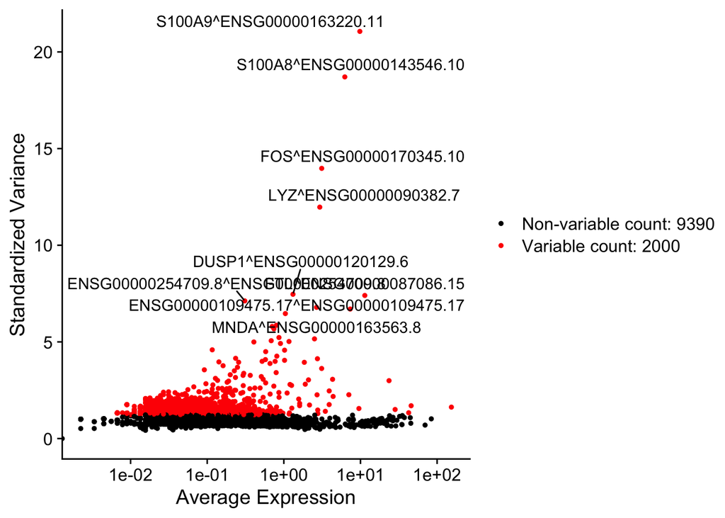

```r
plot2
```

```r
ggsave(filename='VariableFeatures.png',path='/Users/akhorgad/Desktop/MDL/RTD/kinnex_sc/scIsoquantMatrixBuilder_Results', plot = last_plot())
```

ScaleData: Scales and centers features in the dataset. If variables are provided in vars.to.regress, they are individually regressed against each feature, and the resulting residuals are then scaled and centered.

```r
all.features <- rownames(seurat_obj)
seurat_obj <- ScaleData(seurat_obj, features = all.features)
```

Performing PCA :

RunPCA: Run Principal Component Analysis on gene expression using IRLBA. For details about stored PCA calculation parameters, see `PrintPCAParams`.

```r
seurat_obj <- RunPCA(seurat_obj, features = VariableFeatures(object = seurat_obj))
```

```
## PC_ 1
## Positive:  MALAT1^ENSG00000251562.9, RPS12^ENSG00000112306.8, RPL30^ENSG00000156482.11, LTB^ENSG00000227507.3, IL7R^ENSG00000168685.15, RPS8^ENSG00000142937.12, ENSG00000206503.13^ENSG00000206503.13, PRKCQ-AS1^ENSG00000237943.8, TRBC2^ENSG00000211772.11, GZMA^ENSG00000145649.8
##     ENSG00000255819.7^ENSG00000255819.7, ETS1^ENSG00000134954.14, LEF1^ENSG00000138795.10, NKG7^ENSG00000105374.10, KLRB1^ENSG00000111796.4, CD8B^ENSG00000172116.23, CCL5^ENSG00000271503.6, CCR7^ENSG00000126353.3, CST7^ENSG00000077984.6, RCAN3^ENSG00000117602.13
##     LINC02446^ENSG00000256039.3, TRBC1^ENSG00000211751.9, TC2N^ENSG00000165929.13, CD69^ENSG00000110848.8, GZMH^ENSG00000100450.13, novel-gene-chr1-4977^novel-gene-chr1-4977, ENSG00000172183.16^ENSG00000172183.16, ANKRD44-AS1^ENSG00000231621.2, ENSG00000271503.6^ENSG00000271503.6, ENSG00000213626…
## Negative:  MNDA^ENSG00000163563.8, VCAN^ENSG00000038427.16, novel-gene-chr12-3027^novel-gene-chr12-3027, CST3^ENSG00000101439.9, FOS^ENSG00000170345.10, RGS2^ENSG00000116741.8, LYZ^ENSG00000090382.7, FCN1^ENSG00000085265.12, FGL2^ENSG00000127951.8, SERPINA1^ENSG00000197249.14
##     DUSP1^ENSG00000120129.6, CTSS^ENSG00000163131.12, CFD^ENSG00000197766.8, CSTA^ENSG00000121552.4, IFI30^ENSG00000216490.4, S100A8^ENSG00000143546.10, S100A9^ENSG00000163220.11, PSAP^ENSG00000197746.15, S100A12^ENSG00000163221.9, LST1^ENSG00000204482.11
##     novel-gene-chr1-5121^novel-gene-chr1-5121, CYBB^ENSG00000165168.8, CPVL^ENSG00000106066.15, NCF2^ENSG00000116701.15, TYMP^ENSG00000025708.14, GRN^ENSG00000030582.18, CD68^ENSG00000129226.14, FTH1^ENSG00000167996.16, RETN^ENSG00000104918.8, IGSF6^ENSG00000140749.9
## PC_ 2
## Positive:  CD79A^ENSG00000105369.10, IGHM^ENSG00000211899.10, ENSG00000156738.18^ENSG00000156738.18, CD79B^ENSG00000007312.13, HLA-DRA^ENSG00000204287.14, BANK1^ENSG00000153064.12, HLA-DQA1^ENSG00000196735.13, ENSG00000167483.19^ENSG00000167483.19, BCL11A^ENSG00000119866.22, TCL1A^ENSG00000100721…
##     HLA-DRB1^ENSG00000196126.11, TNFRSF13C^ENSG00000159958.7, SWAP70^ENSG00000133789.15, CD74^ENSG00000019582.17, ENSG00000211898.8^ENSG00000211898.8, HLA-DMB^ENSG00000242574.9, VPREB3^ENSG00000128218.8, RALGPS2^ENSG00000116191.19, ENSG00000042980.13^ENSG00000042980.13, ENSG00000211672.2^ENSG0000…
##     AFF3^ENSG00000144218.21, ENSG00000243466.1^ENSG00000243466.1, LINC02397^ENSG00000205056.9, TSPAN13^ENSG00000106537.8, CD22^ENSG00000012124.17, LINC00926^ENSG00000247982.7, ENSG00000077238.14^ENSG00000077238.14, FCER2^ENSG00000104921.15, HLA-DMA^ENSG00000204257.15, ENSG00000081189.16^ENSG00000…
## Negative:  S100A4^ENSG00000196154.12, NKG7^ENSG00000105374.10, GZMA^ENSG00000145649.8, CST7^ENSG00000077984.6, GZMH^ENSG00000100450.13, GNLY^ENSG00000115523.17, CCL5^ENSG00000271503.6, EFHD2^ENSG00000142634.13, PRF1^ENSG00000180644.8, SRGN^ENSG00000122862.5
##     S100A10^ENSG00000197747.9, S100A11^ENSG00000163191.6, S100A6^ENSG00000197956.10, FGFBP2^ENSG00000137441.8, KLRB1^ENSG00000111796.4, CCL4^ENSG00000275302.2, CTSW^ENSG00000172543.9, GZMB^ENSG00000100453.14, ID2^ENSG00000115738.10, ENSG00000255819.7^ENSG00000255819.7
##     ACTB^ENSG00000075624.17, HCST^ENSG00000126264.10, KLRF1^ENSG00000150045.12, ITGB2^ENSG00000160255.18, PLEK^ENSG00000115956.10, ENSG00000211689.7^ENSG00000211689.7, XCL2^ENSG00000143185.4, CX3CR1^ENSG00000168329.14, ZFP36L2^ENSG00000152518.8, KLRD1^ENSG00000134539.17
## PC_ 3
## Positive:  RPS12^ENSG00000112306.8, IL7R^ENSG00000168685.15, RPS8^ENSG00000142937.12, RPL30^ENSG00000156482.11, LTB^ENSG00000227507.3, PRKCQ-AS1^ENSG00000237943.8, RCAN3^ENSG00000117602.13, CCR7^ENSG00000126353.3, RPL34^ENSG00000109475.17, LEF1^ENSG00000138795.10
##     ANKRD44-AS1^ENSG00000231621.2, ENSG00000115687.14^ENSG00000115687.14, PABPC1^ENSG00000070756.17, NOSIP^ENSG00000142546.14, AIF1^ENSG00000204472.13, LRRN3^ENSG00000173114.13, PARP11-AS1^ENSG00000256862.4, LINC02446^ENSG00000256039.3, JUNB^ENSG00000171223.6, COTL1^ENSG00000103187.8
##     LEF1-AS1^ENSG00000232021.8, FAM102A^ENSG00000167106.12, TIMP1^ENSG00000102265.12, ENSG00000197635.11^ENSG00000197635.11, CPA5^ENSG00000158525.16, ENSG00000126883.18^ENSG00000126883.18, ENSG00000070718.12^ENSG00000070718.12, ENSG00000227945.1^ENSG00000227945.1, MAML2^ENSG00000184384.14, MGAT4A…
## Negative:  NKG7^ENSG00000105374.10, GNLY^ENSG00000115523.17, GZMB^ENSG00000100453.14, GZMH^ENSG00000100450.13, CST7^ENSG00000077984.6, FGFBP2^ENSG00000137441.8, EFHD2^ENSG00000142634.13, PRF1^ENSG00000180644.8, GZMA^ENSG00000145649.8, PLEK^ENSG00000115956.10
##     CCL5^ENSG00000271503.6, KLRF1^ENSG00000150045.12, CCL4^ENSG00000275302.2, CTSW^ENSG00000172543.9, TRDC^ENSG00000211829.9, XCL2^ENSG00000143185.4, CLIC3^ENSG00000169583.13, ENSG00000211689.7^ENSG00000211689.7, KLRD1^ENSG00000134539.17, FCGR3A^ENSG00000203747.12
##     ENSG00000187037.9^ENSG00000187037.9, ZEB2^ENSG00000169554.23, CX3CR1^ENSG00000168329.14, TRGC2^ENSG00000227191.8, novel-gene-chr12-665^novel-gene-chr12-665, HLA-DRB1^ENSG00000196126.11, ENSG00000211829.9^ENSG00000211829.9, HLA-DQA1^ENSG00000196735.13, KLRC2^ENSG00000205809.11, IL2RB^ENSG00000…
## PC_ 4
## Positive:  HBEGF^ENSG00000113070.8, MCEMP1^ENSG00000183019.8, ENSG00000214736.8^ENSG00000214736.8, ENSG00000274536.8^ENSG00000274536.8, NFE2^ENSG00000123405.14, CDKN1A^ENSG00000124762.14, ENSG00000197223.12^ENSG00000197223.12, ENSG00000174791.11^ENSG00000174791.11, ENSG00000182287.15^ENSG00000182…
```

[output cut: 12 more lines]

VizDimLoadings: Visualize top genes associated with reduction components:

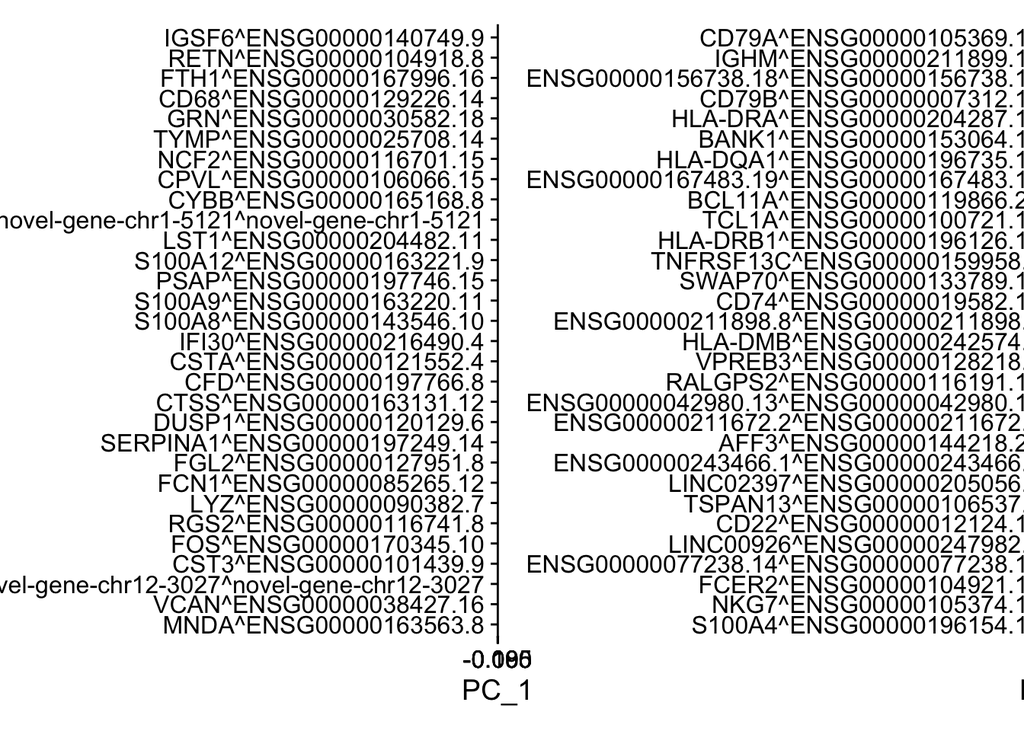

```r
VizDimLoadings(seurat_obj, dims = 1:2, reduction = "pca")
```

DimPlot: Graphs the output of a dimensional reduction technique (PCA by default). Cells are colored by their identity class.

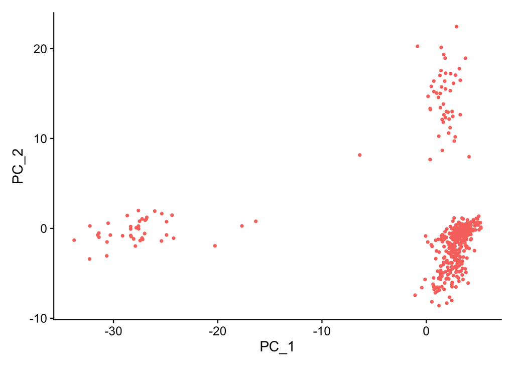

```r
DimPlot(seurat_obj, reduction = "pca") + NoLegend()
```

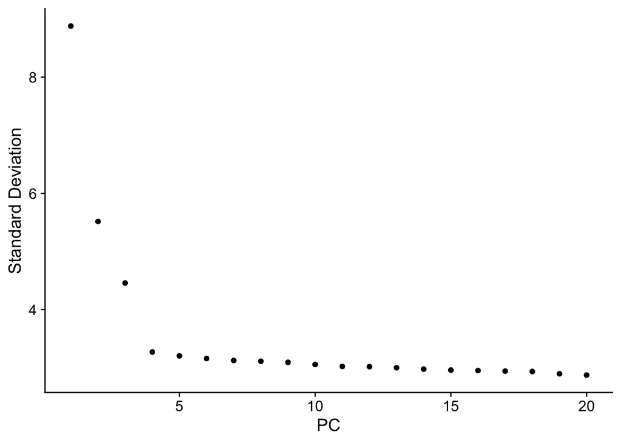

```r
#DimHeatmap(seurat_obj, dims = 1, cells = NULL, balanced = TRUE)

ggsave(filename='DimPlot.png',path='/Users/akhorgad/Desktop/MDL/RTD/kinnex_sc/', plot = last_plot())
# DimHeatmap(
#   object,
#   dims = 1,
#   nfeatures = 30,
#   cells = NULL,
#   reduction = "pca",
#   disp.min = -2.5,
#   disp.max = NULL,
#   balanced = TRUE,
#   projected = FALSE,
#   ncol = NULL,
#   fast = TRUE,
#   raster = TRUE,
#   slot = "scale.data",
#   assays = NULL,
#   combine = TRUE
# )


ElbowPlot(seurat_obj)
```

```r
ggsave(filename='ElbowPlot.png',path='/Users/akhorgad/Desktop/MDL/RTD/kinnex_sc/', plot = last_plot())
```

Generating UMAP :

```r
seurat_obj <- FindNeighbors(seurat_obj, dims = 1:10)
seurat_obj <- FindClusters(seurat_obj, resolution = 0.5)
```

```
## Modularity Optimizer version 1.3.0 by Ludo Waltman and Nees Jan van Eck
##
## Number of nodes: 447
## Number of edges: 16974
##
## Running Louvain algorithm...
## Maximum modularity in 10 random starts: 0.8234
## Number of communities: 4
## Elapsed time: 0 seconds
```

```r
seurat_obj <- RunUMAP(seurat_obj, dims = 1:10)
```

```
## Found more than one class "dist" in cache; using the first, from namespace 'BiocGenerics'
```

```
## Also defined by 'spam'
```

```
## Found more than one class "dist" in cache; using the first, from namespace 'BiocGenerics'
```

```
## Also defined by 'spam'
```

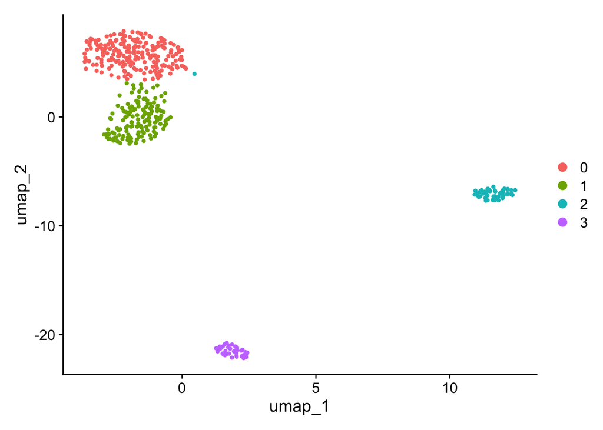

```r
DimPlot(seurat_obj, reduction = "umap")
```

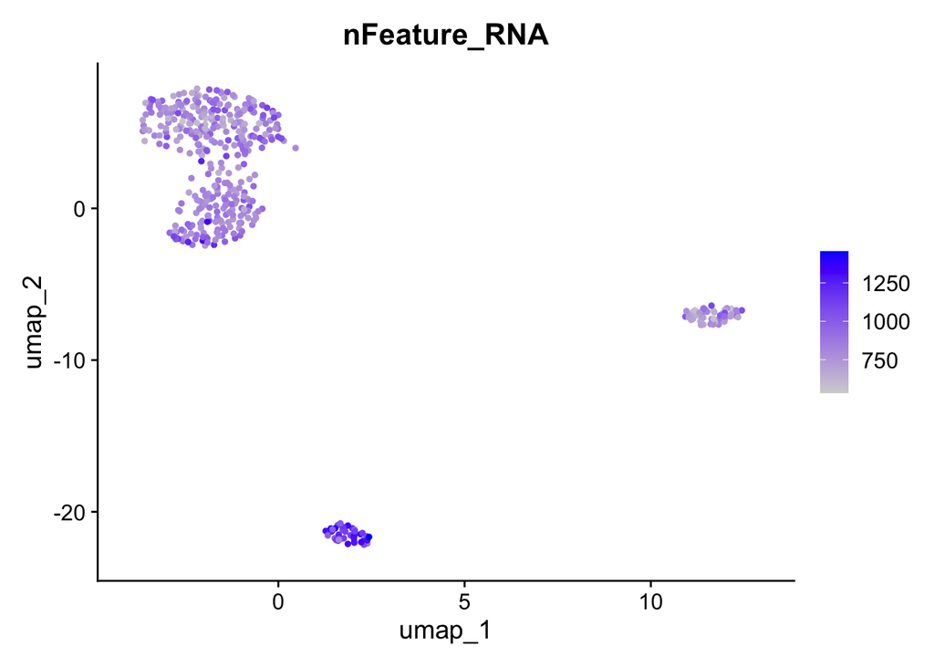

```r
ggsave(filename='UMAP_DimPlot.png',path='/Users/akhorgad/Desktop/MDL/RTD/kinnex_sc/', plot = last_plot())
FeaturePlot(seurat_obj, features = c("nFeature_RNA"))
```

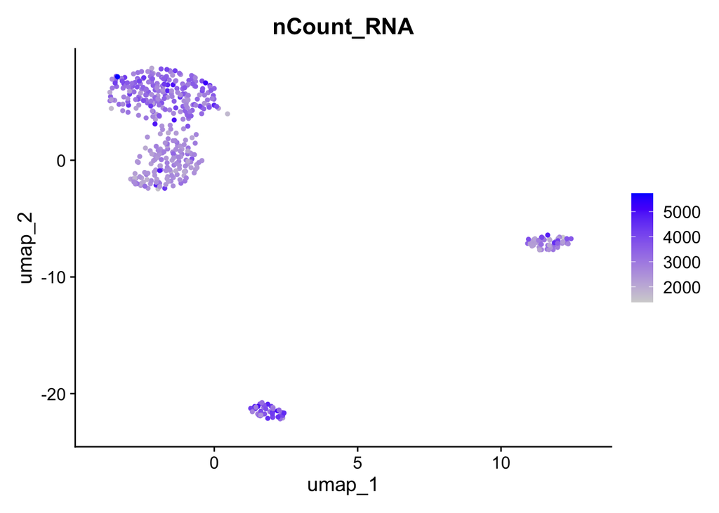

```r
ggsave(filename='nFeature_RNA_FeaturePlot.png',path='/Users/akhorgad/Desktop/MDL/RTD/kinnex_sc/', plot = last_plot())
FeaturePlot(seurat_obj, features = c("nCount_RNA"))
```

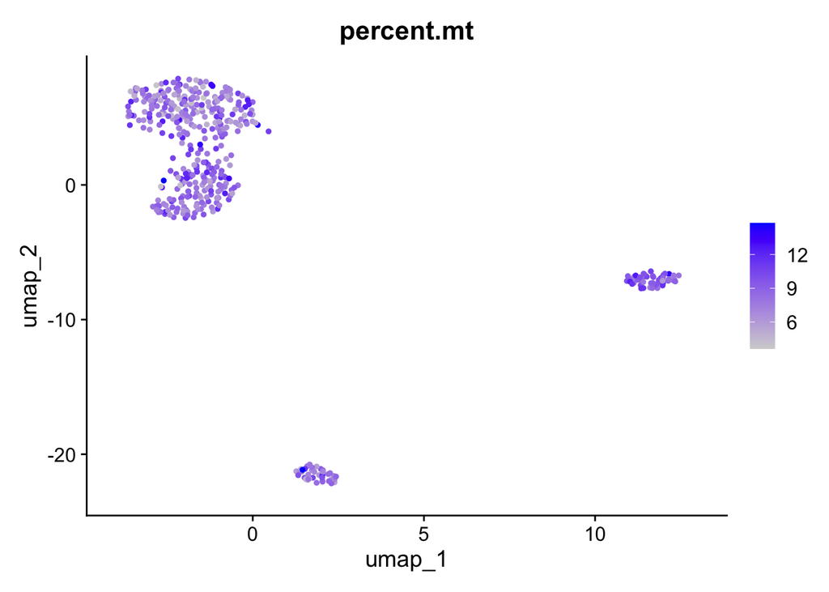

```r
ggsave(filename='nCount_RNA_FeaturePlot.png',path='/Users/akhorgad/Desktop/MDL/RTD/kinnex_sc/', plot = last_plot())
FeaturePlot(seurat_obj, features = c("percent.mt"))
```

```r
ggsave(filename='percent_mt_FeaturePlot.png',path='/Users/akhorgad/Desktop/MDL/RTD/kinnex_sc/', plot = last_plot())
```

Save Seurat object:

```r
saveRDS(seurat_obj, file = paste0(data_dir,output_prefix, "-seurat_obj.rds"))
```

# counts and fractions of cells

```r
cluster_counts_n_fracs = seurat_obj@meta.data %>% group_by(seurat_clusters) %>% tally() %>%  mutate(frac=prop.table(n))

cluster_counts_n_fracs
```

```
## # A tibble: 4 × 3
##   seurat_clusters     n   frac
##   <fct>           <int>  <dbl>
## 1 0                 214 0.479
## 2 1                 144 0.322
## 3 2                  48 0.107
## 4 3                  41 0.0917
```

```r
#saveRDS(seurat_obj, file = paste0(output_prefix, "-seurat_obj.rds"))
```

DE, find markers: - find markers for every cluster compared to all remaining cells, report only the positive ones

```r
#{r}

seurat_obj.markers <- FindAllMarkers(seurat_obj, only.pos = TRUE)
```

[output not shown]

```r
seurat_obj.markers %>%
    group_by(cluster) %>%
    dplyr::filter(avg_log2FC > 1)
```

```
## # A tibble: 2,546 × 7
## # Groups:   cluster [4]
##       p_val avg_log2FC pct.1 pct.2 p_val_adj cluster gene
##       <dbl>      <dbl> <dbl> <dbl>     <dbl> <fct>   <chr>
##  1 2.23e-44       2.25 0.93  0.245  2.54e-40 0       IL7R^ENSG00000168685.15
##  2 7.45e-35       1.66 0.977 0.459  8.49e-31 0       LTB^ENSG00000227507.3
##  3 1.65e-25       2.96 0.57  0.099  1.88e-21 0       PRKCQ-AS1^ENSG00000237943.8
##  4 1.08e-21       1.08 0.78  0.609  1.23e-17 0       RPL34^ENSG00000109475.17
##  5 1.20e-21       1.25 0.907 0.601  1.37e-17 0       GAS5^ENSG00000234741.9
##  6 2.17e-19       2.10 0.561 0.146  2.47e-15 0       TCF7^ENSG00000081059.20
##  7 3.76e-19       3.34 0.397 0.052  4.29e-15 0       RCAN3^ENSG00000117602.13
##  8 4.96e-17       2.95 0.397 0.064  5.65e-13 0       LEF1^ENSG00000138795.10
##  9 4.15e-15       3.24 0.336 0.047  4.73e-11 0       CCR7^ENSG00000126353.3
## 10 3.27e-14       2.11 0.397 0.086  3.72e-10 0       CD27^ENSG00000139193.4
## # ℹ 2,536 more rows
```

```r
top_20_markers = seurat_obj.markers %>%
group_by(cluster) %>%
dplyr::filter(avg_log2FC > 1) %>% slice_head(n=20) %>% ungroup()


top_20_markers
```

```
## # A tibble: 80 × 7
##       p_val avg_log2FC pct.1 pct.2 p_val_adj cluster gene
##       <dbl>      <dbl> <dbl> <dbl>     <dbl> <fct>   <chr>
##  1 2.23e-44       2.25 0.93  0.245  2.54e-40 0       IL7R^ENSG00000168685.15
##  2 7.45e-35       1.66 0.977 0.459  8.49e-31 0       LTB^ENSG00000227507.3
##  3 1.65e-25       2.96 0.57  0.099  1.88e-21 0       PRKCQ-AS1^ENSG00000237943.8
##  4 1.08e-21       1.08 0.78  0.609  1.23e-17 0       RPL34^ENSG00000109475.17
##  5 1.20e-21       1.25 0.907 0.601  1.37e-17 0       GAS5^ENSG00000234741.9
##  6 2.17e-19       2.10 0.561 0.146  2.47e-15 0       TCF7^ENSG00000081059.20
##  7 3.76e-19       3.34 0.397 0.052  4.29e-15 0       RCAN3^ENSG00000117602.13
##  8 4.96e-17       2.95 0.397 0.064  5.65e-13 0       LEF1^ENSG00000138795.10
##  9 4.15e-15       3.24 0.336 0.047  4.73e-11 0       CCR7^ENSG00000126353.3
## 10 3.27e-14       2.11 0.397 0.086  3.72e-10 0       CD27^ENSG00000139193.4
## # ℹ 70 more rows
```

```r
max_cluster <- max(as.numeric(top_20_markers$cluster)) - 1

for (clnum in 0:max_cluster) {
    cluster = top_20_markers %>% filter(cluster == clnum)

        gene.symbols = sapply(cluster$gene, function(x) { str_split(x, "\\^")[[1]][1] })

        gene.symbols = grep("ENSG|ENST|novel", gene.symbols, value=T, invert=T)

    cat(paste0(clnum,":"))
    cat(gene.symbols, sep=",")
    cat("\n")
}
```

```
## 0:IL7R,LTB,PRKCQ-AS1,RPL34,GAS5,TCF7,RCAN3,LEF1,CCR7,CD27,MAL,ANKRD44-AS1,RGCC,NOSIP,RGS10,CAMK4,AQP3,TRAC
## 1:NKG7,CST7,GZMH,GZMA,GNLY,CCL5,FGFBP2,CCL4,PRF1,PLEK,EFHD2,GZMM,CALM1,HOPX,PFN1,CTSW,GZMB,IFITM1,TRGC2,XCL2
## 2:CD79A,IGHM,BANK1,CD79B,HLA-DQA1,BCL11A,TCL1A,TNFRSF13C,HLA-DRA,VPREB3,RALGPS2,SWAP70,HLA-DMB,HLA-DRB1
## 3:CSTA,CFD,SERPINA1,MNDA,VCAN,RGS2,NCF2,CPVL,CD68,FGL2,LST1,CYBB,GRN,CST3,RETN,FCN1,IFI30
```

Run above list through: http://xteam.xbio.top/ACT to get cell type predictions.

Installing clustermole: https://cran.rstudio.com/web/packages/clustermole/vignettes/clustermole-intro.html

```r
BiocManager::install("igordot/clustermole", update = FALSE)
```

using clustermole to add annotations:

```r
library(clustermole)

clustermole_results = NULL

for (clnum in 0:max_cluster) {
  cluster = top_20_markers %>% filter(cluster == clnum)

  gene.symbols = sapply(cluster$gene, function(x) { str_split(x, "\\^")[[1]][1] })

  gene.symbols = grep("ENSG|ENST|novel", gene.symbols, value=T, invert=T)


  tryCatch(
    expr = {

      cat(paste0(clnum,":"))
    cat(gene.symbols, sep=",")
    cat("\n")

    my_overlaps <- clustermole_overlaps(genes = gene.symbols, species = "hs")

    clustermole_results = bind_rows(clustermole_results,
                                  my_overlaps %>% mutate(clnum = clnum))
    },
    error = function(e){
       message("Error: ", e)
    },
    warning = function(w){
      message("Warning: ", w)
    }
  )
}
```

```
## 0:IL7R,LTB,PRKCQ-AS1,RPL34,GAS5,TCF7,RCAN3,LEF1,CCR7,CD27,MAL,ANKRD44-AS1,RGCC,NOSIP,RGS10,CAMK4,AQP3,TRAC
## 1:NKG7,CST7,GZMH,GZMA,GNLY,CCL5,FGFBP2,CCL4,PRF1,PLEK,EFHD2,GZMM,CALM1,HOPX,PFN1,CTSW,GZMB,IFITM1,TRGC2,XCL2
## 2:CD79A,IGHM,BANK1,CD79B,HLA-DQA1,BCL11A,TCL1A,TNFRSF13C,HLA-DRA,VPREB3,RALGPS2,SWAP70,HLA-DMB,HLA-DRB1
## 3:CSTA,CFD,SERPINA1,MNDA,VCAN,RGS2,NCF2,CPVL,CD68,FGL2,LST1,CYBB,GRN,CST3,RETN,FCN1,IFI30
```

```r
clustermole_summary = clustermole_results  %>% filter(db == "PanglaoDB") %>%
  group_by(clnum) %>% arrange(p_value) %>% filter(row_number() == 1) %>% arrange(clnum) %>%
  ungroup() %>%
  dplyr::select(clnum, organ, celltype, fdr)

clustermole_summary
```

```
## # A tibble: 4 × 4
##   clnum organ         celltype            fdr
##   <int> <chr>         <chr>             <dbl>
## 1     0 Immune system T memory cells 1.47e- 8
## 2     1 Immune system NK cells       1.04e-18
## 3     2 Immune system B cells        1.52e-19
## 4     3 Immune system Macrophages    1.94e- 3
```

```r
write.table(clustermole_summary, file = paste0(data_dir, output_prefix, "-clustermole.tsv"), quote=F, row.names=F, sep="\t")
```

```r
# save files for later read/cell tracking

write.table( Idents(seurat_obj), paste0(data_dir, output_prefix, "-cell_cluster_assignments.tsv"), quote=F, row.names=T, sep="\t")
```

```r
saveRDS(seurat_obj, file = paste0(data_dir, output_prefix, "-seurat_obj.rds"))
```

Select Tissue type blood

```r
# example definition of marker genes for certain cell types

marker_genes = list()

marker_genes[["CD8"]] = c("CD8A","CD8B","GZMB","TRB","TRA","PRF1", "GZMB")
```

# function to extract gene ids with the relevant gene symbols

```r
#{r}

# function to extract gene ids with the relevant gene symbols


feature_names = rownames(seurat_obj@assays$RNA$counts)

get_feature_names_with_gene_symbols = function(gene_symbols) {

gene_ids = c()

for (gene_symbol in gene_symbols) {
    found_genes = grep(paste0(gene_symbol,"\\^"), feature_names, value=T)
 if (length(found_genes) > 0) {
        gene_ids = c(gene_ids, found_genes)
    }
}
return(gene_ids)
}
```

# paint umaps according to the features of interest

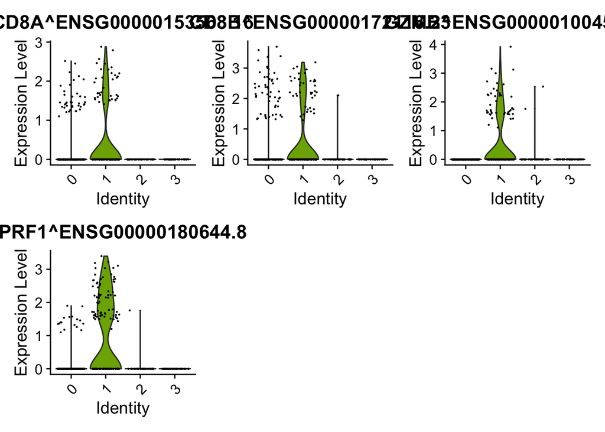

```r
# paint umaps according to the features of interest

feature_ids = get_feature_names_with_gene_symbols(marker_genes[["CD8"]])

VlnPlot(seurat_obj, features = feature_ids)
```

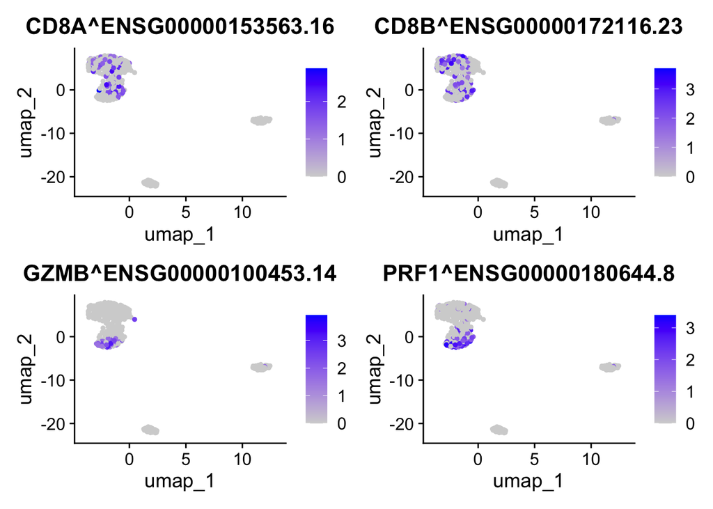

```r
ggsave(filename='foi_VlnPlot.png',path='/Users/akhorgad/Desktop/MDL/RTD/kinnex_sc/', plot = last_plot())
FeaturePlot( seurat_obj, features = feature_ids)
```

```r
ggsave(filename='foi_FeaturePlot.png',path='/Users/akhorgad/Desktop/MDL/RTD/kinnex_sc/', plot = last_plot())
```